# HW 5

Jan Netík

### 1.1.1

$b_0$ is value of log-odds when $X=0$  
$b_1$ represents a change in log-odds when $X$ increase by 1

### 1.1.2

```r
# probability computation based on three parameters
compute_p <- function(x, b0, b1) {
  exp(b0 + b1 * x) / (1 + exp(b0 + b1 * x))
}

# values of X
x <- c(0, 5, 10, 15, 20)

# make table
table <- tibble(x = x,
                p = compute_p(x, -5, .5))

# show it
table %>% rename("Total score $X$" = x, "$P(Y = 1 | X, b_0, b_1)$" = p) %>% pander(digits = 2)
```

| Total score $X$ | $P(Y = 1 \| X, b_0, b_1)$ |
| --- | --- |
| 0 | 0.0067 |
| 5 | 0.076 |
| 10 | 0.5 |
| 15 | 0.92 |
| 20 | 0.99 |

### 1.1.3

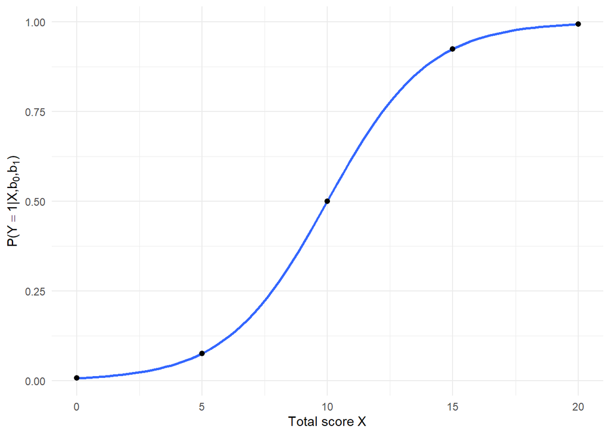

```r
table %>% ggplot(aes(x, p)) + geom_smooth(
  method = "glm",
  method.args = list(family = "binomial"),
  se = F
) +
  geom_point(size = 1.75) +
  labs(x = "Total score X", y = TeX("$P(Y = 1 | X, b_0, b_1)$")) +
  theme_minimal()
```

### 1.2.1

$b_0 = -5$  
$b_1 = 0.5$

$M_X = 10$  
$SD_X = 3$

$\tilde{b_0} =\ ?$  
$\tilde{b_1} =\ ?$

$$P(Y = 1 | X, b_0, b_1) = P(Y = 1 | Z, \tilde{b_0}, \tilde{b_1})$$
$$\frac{\exp(b_0 + b_1X)}{1 + \exp(b_0 + b_1X)} = \frac{\exp(\tilde{b_0} + \tilde{b_1}Z)}{1 + \exp(\tilde{b_0} + \tilde{b_1}Z)}$$
$$b_0 + b_1X = \tilde{b_0} + \tilde{b_1}Z$$
$$b_0 + b_1X = \tilde{b_0} + \tilde{b_1}\frac{X-M_X}{SD_X}$$

Considering $X = M_X$:

$$b_0 + b_1M_X = \tilde{b_0} + \tilde{b_1}\frac{M_X-M_X}{SD_X}$$
$$b_0 =\tilde{b_0} - b_1M_X$$

$$\tilde{b_0} = b_0 + b_1M_X = -5 + 0.5\cdot10 = 0$$

Now let’s consider $X = 1$ and substitute $b_0$ with its value above:

$$b_0 + b_1 = \tilde{b_0} + \tilde{b_1}\frac{1-M_X}{SD_X}$$
$$\tilde{b_0} - b_1M_X + b_1 = \tilde{b_0} + \tilde{b_1}\frac{1-M_X}{SD_X}$$
$$b_1(1-M_X) = \tilde{b_1}\frac{1-M_X}{SD_X}$$
$$b_1 = \frac{\tilde{b_1}}{SD_X}$$
$$\tilde{b_1} = b_1SD_X$$
$$\tilde{b_1} = 0.5 \cdot 3 = 1.5$$

### 1.2.2

$\tilde{b_0}$ is the value of log-odds for average $X$ (i.e. $Z = 0$). $\tilde{b_1}$ has now value of $1.5$ and was acquired by multiplying $b_1$ with $SD_X$, so it is now on the same scale as $Z$. We can interpret it as a change of log-odds associated with increase of the original variable X *by one standard deviation.*

### 1.3.1

$$\tilde{b_0} + \tilde{b_1}Z = a(Z-b)$$
Considering $Z = b$:
$$\tilde{b_0} + \tilde{b_1}b = a(b-b)$$
$$\tilde{b_0} + \tilde{b_1}b = ab-ab$$
$$\tilde{b_1}b = -\tilde{b_0}$$
$$b = -\frac{\tilde{b_0}}{\tilde{b_1}} = - \frac{0}{1.5} = 0$$

Considering $Z = 0$:

$$\tilde{b_0} + \tilde{b_1}Z = a(Z-b)$$
$$\tilde{b_0} + \tilde{b_1}Z = aZ-ab$$
$$\tilde{b_1}Z - aZ =- \tilde{b_0} -ab$$
$$Z(\tilde{b_1} - a) = - \tilde{b_0} -ab$$
$$\tilde{b_0} = -ab$$
$$\tilde{b_0} = \frac{ab_0}{b_1}$$
$$\tilde{b_0}\tilde{b_1} = ab_0$$
$$a = \tilde{b_1} = 1.5$$

### 1.3.2

$a$ is “discrimination index”, slope at inflexion point (where $Z = b$), log-odds change when $Z$ increases by one unit. $b$ is “difficulty index”, horizontal location of inflexion point, a value of $Z$ that gives $P(Y=1|Z=b)=0.5$.

### 2.1.1

$c$ can be viewed as “(pseudo)-guess rate” (probability of correct answer even if $Z$ is minimal – testee does not know correct answer, yet he/she get it right):
$$c = \lim_{Z \to -\infty} P(Y = 1 | Z, a, b, c, d)$$
$1-d$ can be called “lapse rate” or “inattention” (probability of *incorrect* answer even if $Z$ is large – testee knows correct answer, but chooses distractor instead):
$$d = \lim_{Z \to +\infty} P(Y = 1 | Z, a, b, c , d)$$

### 2.1.2

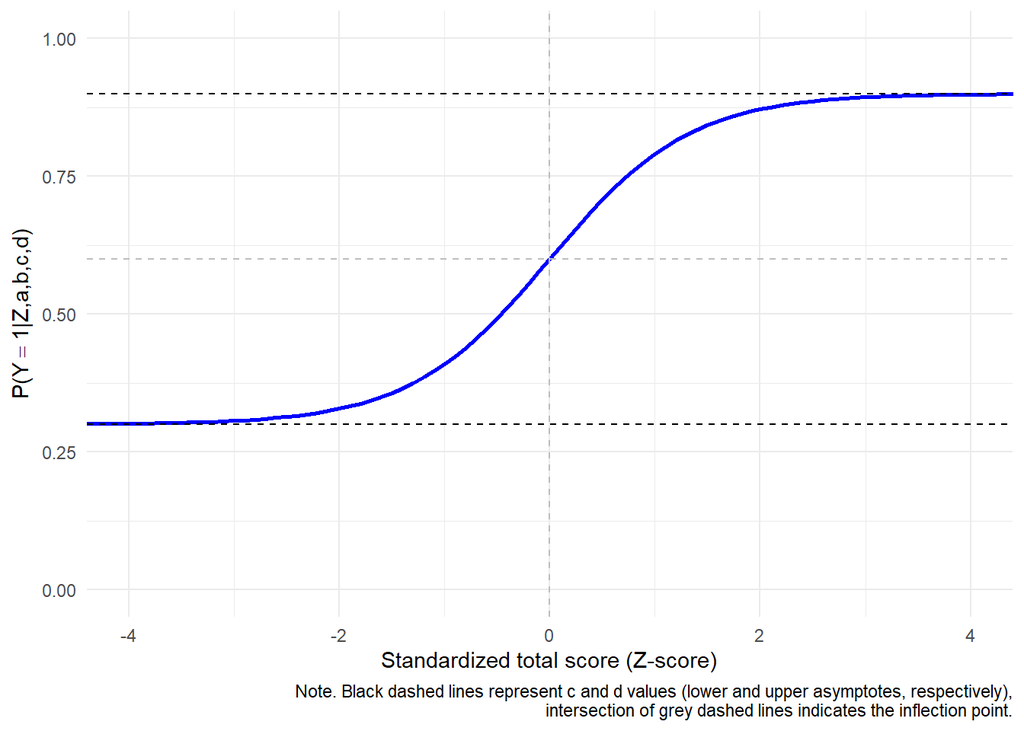

```r
# define function for probability computation
pl4 <- function(z, a, b, c, d) {
  c + (d - c) * ((exp(a * (z - b))) / (1 + exp(a * (z - b))))
}

# plot function above
ggplot(data.frame(z = c(-5, 5)), aes(z)) + stat_function(
  fun = pl4,
  args = list(
    a = 1.5,
    b = 0,
    c = .3,
    d = .9
  ),
  col = "blue",
  size = 1
) + labs(x = "Standardized total score (Z-score)",
         y = TeX("$P(Y = 1 | Z, a, b, c, d)$"),
         caption = "Note. Black dashed lines represent c and d values (lower and upper asymptotes, respectively),\n intersection of grey dashed lines indicates the inflection point.") +
  ylim(0, 1) +
  coord_cartesian(xlim = c(-4, 4)) +
  geom_hline(yintercept = .3, linetype = "dashed") + # c
  geom_hline(yintercept = .9, linetype = "dashed") + # d
  geom_vline(xintercept = 0,
             linetype = "dashed",
             col = "grey") +
  geom_hline(
    yintercept = pl4(
      0,
      a = 1.5,
      b = 0,
      c = .3,
      d = .9
    ),
    linetype = "dashed",
    col = "grey"
  ) +
  theme_minimal()
```

As shown in the plot above, the $P(Y=1|Z=b)=0.5$ does not longer hold true. It is now impossible to obtain values $P \notin (c, d)$. We have to implement the parameters *c* and *d*:
$$P(Y=1|Z=b, a, b = Z, c , d) = \frac{c+d}{2}$$

As already visualized in the plot, probability of success at inflection point is $P(Y=1|Z=0, a = 1.5, b = 0, c =0.3 , d=0.9) = \frac{0.3 + 0.9}{2} = 0.6$. Location of the inflexion point changes, so $b$ must conform $P(Y=1|Z=b, a, b = Z, c , d) = \frac{c+d}{2}$. When $c = 0$ and $d = 1$, the probability is again $(0+1)/2 = 0.5$, as in the “2PL” model.

### 2.2.1

```r
# define function for probability computation based on IRT parametrization
compute_p_irt <- function(z, a, b) {
  exp(a * (z - b))
}

# generate Zs, make sure to include those from assignment
z <- c(seq(-5, 5, length.out = 500), c(c(-1.8,-.6, 0, .6, 1.8)))

# make data frame out of computed probabilities
df <- data.frame(
  k0 = compute_p_irt(z, 0, 0),
  k1 = compute_p_irt(z, 1.5,-0.6),
  k2 = compute_p_irt(z, 2, 0)
)

# divide by sum of rows
df_sum <- df  / rowSums(df)

# add column indicating from which Z is probability computed for
df_sum %<>% add_column(.before = 1, z = z)

# prepare table (only for aforementioned five Zs)
df_trans <- df_sum %>% filter(z %in% c(-1.8, -.6, 0, .6, 1.8)) %>% t() # transpose

colnames(df_trans) <- df_trans[1, ] # make column names out of the first row

df_trans <- df_trans[-1, ] # remove redundant row

df_trans %>% pander(digits = 2) # print
```

|  | -1.8 | -0.6 | 0 | 0.6 | 1.8 |
| --- | --- | --- | --- | --- | --- |
| **k0** | 0.84 | 0.43 | 0.22 | 0.096 | 0.013 |
| **k1** | 0.14 | 0.43 | 0.55 | 0.58 | 0.49 |
| **k2** | 0.023 | 0.13 | 0.22 | 0.32 | 0.49 |

### 2.2.2

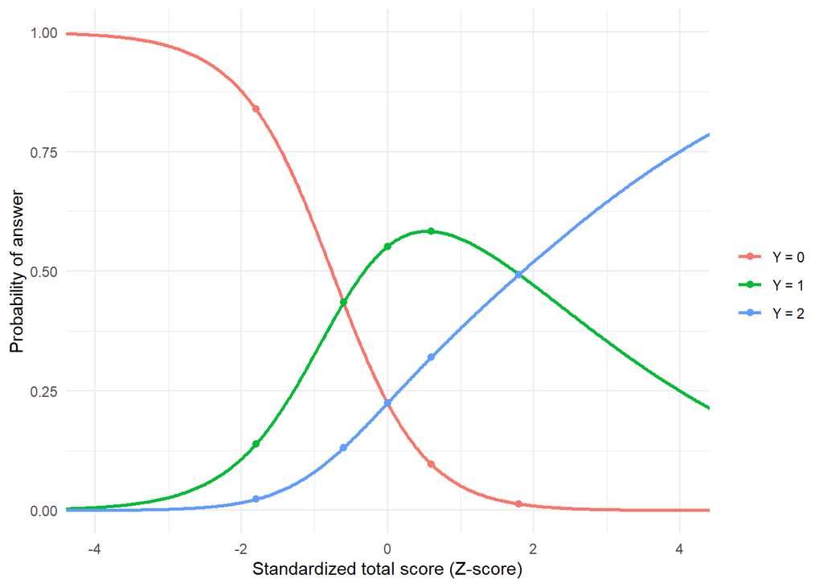

```r
# convert to long format (prepare for plotting)
df_sum %<>% as_tibble %>% pivot_longer(
  cols = c("k0", "k1", "k2"),
  values_to = "p",
  names_to = "k"
)

# filter out assignment Zs
points <- df_sum %>% filter(z %in% c(-1.8, -.6, 0, .6, 1.8))

# plot lines from sequence generated in section 2.2.1, highlight the assignment points
df_sum %>% ggplot(aes(z, p, col = factor(
  k,
  levels = c("k0", "k1", "k2"),
  labels = c("Y\ =\ 0", "Y\ =\ 1", "Y\ =\ 2")
))) +
  geom_line(size = 1) +
  geom_point(data = points, size = 1.75) +
  coord_cartesian(xlim = c(-4, 4)) +
  labs(x = "Standardized total score (Z-score)", y = "Probability of answer", col = "") +
  theme_minimal()
```

Curves cross at $Z = -0.6, 0, 1.8$.

### 3.1

The best fitting model for item 4 is **3PL**, with estimated parameters $a = 1.63$, $b = 1.24$, and $c = 0.25$. The probability of correct answer at inflection point is:
$$P(Y=1|Z=b=1.24, a = 1.63, b = 1.24, c =0.25)=\frac{1+c}{2} = \frac{1.25}{2} = 0.625$$
Thus, at the inflection point, $Z = b = 1.24$. Testee with $Z = 1.24$ has probability $0.625$ that he or she answers the item right (it can be considered 0.5, when we “correct” for guessing). One-unit increase in the Z-score means the **odds** of answering the item correctly raise $5.11\times$. Probability of guessing the correct answer is $c = 0.25$.

### 3.2

The best fitting model for item 19 is **2PL**, with estimated parameters $a = 1.37$, $b = -1.27$. The probability of correct answer at inflection point is:
$$P(Y=1|Z=b=-1.27, a = 1.37, b = -1.27) =0.5$$
Thus, at the inflection point, $Z = b = -1.27$. Testee with $Z = -1.27$ has probability $0.5$ that he or she answers the item right. One-unit increase in the Z-score means the **odds** of answering the item correctly raise $3.94\times$.

### 4

Term “lapse rate” introduced in psychophysics: https://www.sciencedirect.com/book/9780124071568/psychophysics